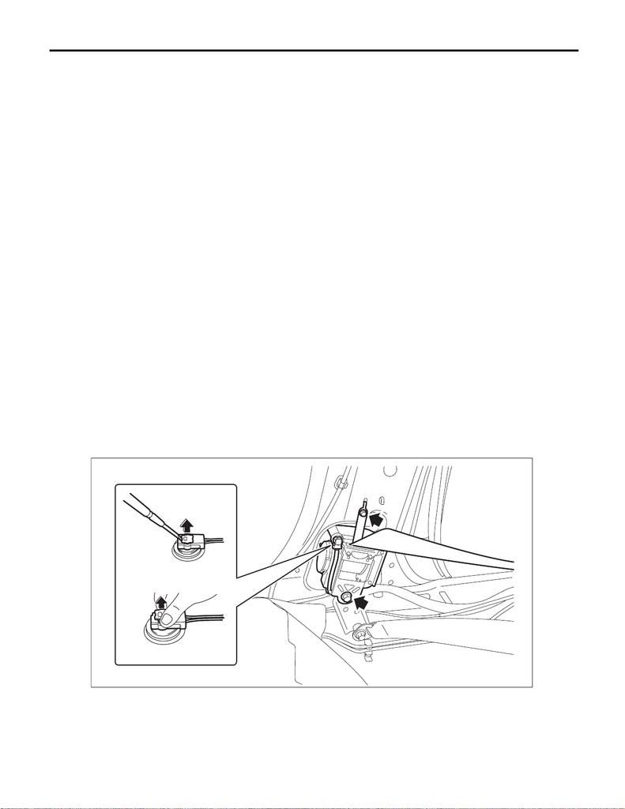

AB-54

Side Airbag Sensor

AIRBAG SYSTEM

12.Side Airbag Sensor

A: REMOVAL

CAUTION:

• Airbag system satellite safing sensor is located in the lower of the rear seat cushion center. Before

removing the rear seat, refer to “CAUTION” of “General Description” in “AIRBAG SYSTEM” section.

<Ref. to AB-9, CAUTION, General Description.>

tem.

1) Move the seat all the way forward, from which the side airbag sensor is to be removed.

NOTE:

This is to remove the seat belt retractor assembly.

2) Turn the ignition switch to OFF.

3) Disconnect the ground cable from battery and wait for at least 60 seconds before starting work. <Ref. to

NT-5, BATTERY, NOTE, Note.>

NOTE:

• For models other than STI model, disconnect the ground terminal from battery sensor.

• For model with the power seat, move the seat to the front-most position before removing the battery

ground terminal.

4) Remove the cover side sill - front INN, cover side sill - rear INN, and trim panel - center pillar LWR. <Ref.

to EI-81, REMOVAL, Lower Inner Trim.>

5) Remove the rear seat cushion assembly. <Ref. to SE-29, REMOVAL, Rear Seat.>

6) Remove the seat belt retractor. (On the side where the side airbag sensor is removed)

NOTE:

Also disconnect the connector of the passenger’s lap seat belt pretensioner.

(2) Remove the bolt to remove the seat belt retractor.

AB-02907

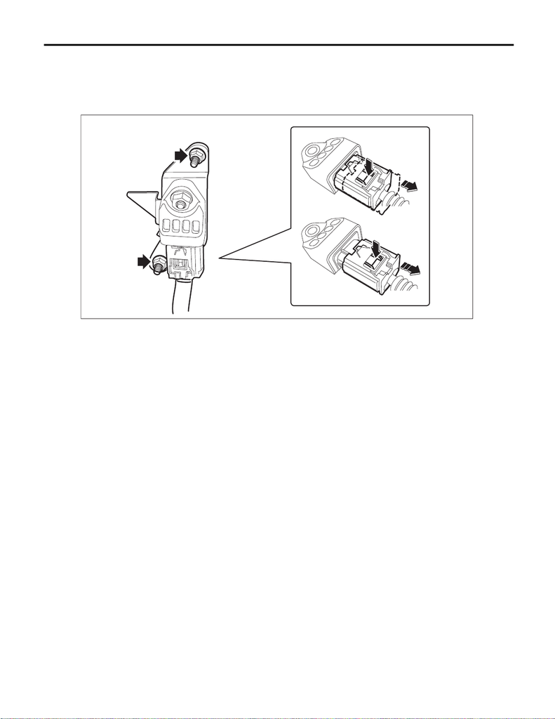

AB-55

Side Airbag Sensor

AIRBAG SYSTEM

7) Remove the nuts and then remove the side airbag sensor. <Ref. to AB-22, SIDE AIRBAG SENSOR AND

CURTAIN AIRBAG SENSOR, PROCEDURE, Airbag Connector.>

CAUTION:

• Do not separate the side airbag sensor and bracket. It causes the airbag system malfunction.

• If the sensor is removed from the bracket, be sure to replace with a new part.

B: INSTALLATION

1) Before installation, inspect the following items and replace any faulty part with a new part.

• The side airbag sensor, sensor bracket, or connector are damaged.

• Side airbag module has been activated.

2) Install the side airbag sensor.

CAUTION:

Do not reuse the bolt and nut.

Always replace with the specified new bolts and nuts.

Tightening torque:

7.5 N·m (0.8 kgf-m, 5.5 ft-lb)

3) Install the seat belt retractor.

Tightening torque:

Front seat belt: <Ref. to SB-2, FRONT SEAT BELT, COMPONENT, General Description.>

4) Install the cover side sill - front INN, cover side sill - rear INN, and trim panel - center pillar LWR.

5) Connect the battery ground terminal. <Ref. to NT-5, BATTERY, NOTE, Note.>

NOTE:

For models other than STI model, connect the ground terminal to battery sensor.

AB-02909

(3)

(4)

(2)

(1)